# Practical Machine Learning Assignment

Scott Fan

03/08/2018

## Project Introduction

### Background

Using devices such as Jawbone Up, Nike FuelBand, and Fitbit it is now possible to collect a large amount of data about personal activity relatively inexpensively. These type of devices are part of the quantified self movement - a group of enthusiasts who take measurements about themselves regularly to improve their health, to find patterns in their behavior, or because they are tech geeks. One thing that people regularly do is quantify how much of a particular activity they do, but they rarely quantify how well they do it. In this project, your goal will be to use data from accelerometers on the belt, forearm, arm, and dumbell of 6 participants. They were asked to perform barbell lifts correctly and incorrectly in 5 different ways. More information is available from the website here: http://groupware.les.inf.puc-rio.br/har (see the section on the Weight Lifting Exercise Dataset).

### Data

The training data for this project are available here: https://d396qusza40orc.cloudfront.net/predmachlearn/pml-training.csv

The test data are available here: https://d396qusza40orc.cloudfront.net/predmachlearn/pml-testing.csv

The data for this project come from this source: http://groupware.les.inf.puc-rio.br/har. If you use the document you create for this class for any purpose please cite them as they have been very generous in allowing their data to be used for this kind of assignment.

### Objectives

The goal of your project is to predict the manner in which they did the exercise. This is the “classe” variable in the training set. You may use any of the other variables to predict with. You should create a report describing how you built your model, how you used cross validation, what you think the expected out of sample error is, and why you made the choices you did. You will also use your prediction model to predict 20 different test cases.

## Setting up working environment

```r
library(caret)
library(rpart)
library(rpart.plot)
library(RColorBrewer)
library(randomForest)
library(knitr)

set.seed(123)

train <- "http://d396qusza40orc.cloudfront.net/predmachlearn/pml-training.csv"
test <- "http://d396qusza40orc.cloudfront.net/predmachlearn/pml-testing.csv"

training_data <- read.csv(url(train), na.strings=c("NA","#DIV/0!",""))
testing_data <- read.csv(url(test), na.strings=c("NA","#DIV/0!",""))
```

We will partition the training set into a training and test set.

```r
inTrain <- createDataPartition(training_data$classe, p=0.6, list=FALSE)
Train_Training <- training_data[inTrain, ]
Train_Testing <- training_data[-inTrain, ]
dim(Train_Training); dim(Train_Testing)
```

```
## [1] 11776   160
```

```
## [1] 7846  160
```

## Data Cleaning

First of all, we have to remove the near zero variance variables in the data set. This will aid in further analysis down the line.

```r
nzv_index <- nearZeroVar(Train_Training, saveMetrics=TRUE)
myTrain <- Train_Training[,nzv_index$nzv==FALSE]

nzv_index2<- nearZeroVar(Train_Testing,saveMetrics=TRUE)
myTest <- Train_Testing[,nzv_index2$nzv==FALSE]
```

The first 5 column of the data will be removed as they are merely for identification.

```r
myTrain <- myTrain[, -(1:5)]
myTest <- myTest[, -(1:5)]
```

Removing variables with 70% or more NA variables.

```r
training_temp <- myTrain
for(i in 1:length(myTrain)) {
    if( sum( is.na( myTrain[, i] ) ) /nrow(myTrain) >= .7) {
        for(j in 1:length(training_temp)) {
            if( length( grep(names(myTrain[i]), names(training_temp)[j]) ) == 1)  {
                training_temp <- training_temp[ , -j]
            }
        }
    }
}

myTrain <- training_temp
rm(training_temp)


## Making sure only columns that appear in myTrain and in myTest.
myTest <- myTest[,names(myTrain)]
```

## Prediction Model Building

Three methods will be used to model the regression and the one with the highest accuracy will be used for the quiz prediction. These models include:

1. Randiom Forests
2. Decision Trees
3. Generalized Boosting Model

A Confusion Matrix is displayed at the end to provide us an accurate summary.

### Random Forests

```r
set.seed(123)
controls <- trainControl(method="cv", number=3, verboseIter=FALSE)
RandForest <- train(classe ~ ., data=myTrain, method="rf",
                          trControl=controls)
RandForest$finalModel


predictRandForest <- predict(RandForest, newdata=myTest)
confRandForest <- confusionMatrix(predictRandForest, myTest$classe)
confRandForest
```

```
##
## Call:
##  randomForest(x = x, y = y, mtry = param$mtry)
##                Type of random forest: classification
##                      Number of trees: 500
## No. of variables tried at each split: 27
##
##         OOB estimate of  error rate: 0.35%
## Confusion matrix:
##      A    B    C    D    E  class.error
## A 3346    1    0    0    1 0.0005973716
## B    5 2272    2    0    0 0.0030715226
## C    0    8 2043    3    0 0.0053554041
## D    0    0   15 1914    1 0.0082901554
## E    0    0    0    5 2160 0.0023094688
## Confusion Matrix and Statistics
##
##           Reference
## Prediction    A    B    C    D    E
##          A 2232    1    0    0    0
##          B    0 1514    3    0    0
##          C    0    3 1362    6    0
##          D    0    0    3 1280    1
##          E    0    0    0    0 1441
##
## Overall Statistics
##
##                Accuracy : 0.9978
##                  95% CI : (0.9965, 0.9987)
##     No Information Rate : 0.2845
##     P-Value [Acc > NIR] : < 2.2e-16
##
##                   Kappa : 0.9973
##  Mcnemar's Test P-Value : NA
##
## Statistics by Class:
##
##                      Class: A Class: B Class: C Class: D Class: E
## Sensitivity            1.0000   0.9974   0.9956   0.9953   0.9993
## Specificity            0.9998   0.9995   0.9986   0.9994   1.0000
## Pos Pred Value         0.9996   0.9980   0.9934   0.9969   1.0000
## Neg Pred Value         1.0000   0.9994   0.9991   0.9991   0.9998
## Prevalence             0.2845   0.1935   0.1744   0.1639   0.1838
## Detection Rate         0.2845   0.1930   0.1736   0.1631   0.1837
## Detection Prevalence   0.2846   0.1933   0.1747   0.1637   0.1837
## Balanced Accuracy      0.9999   0.9984   0.9971   0.9974   0.9997
```

### Decision Trees

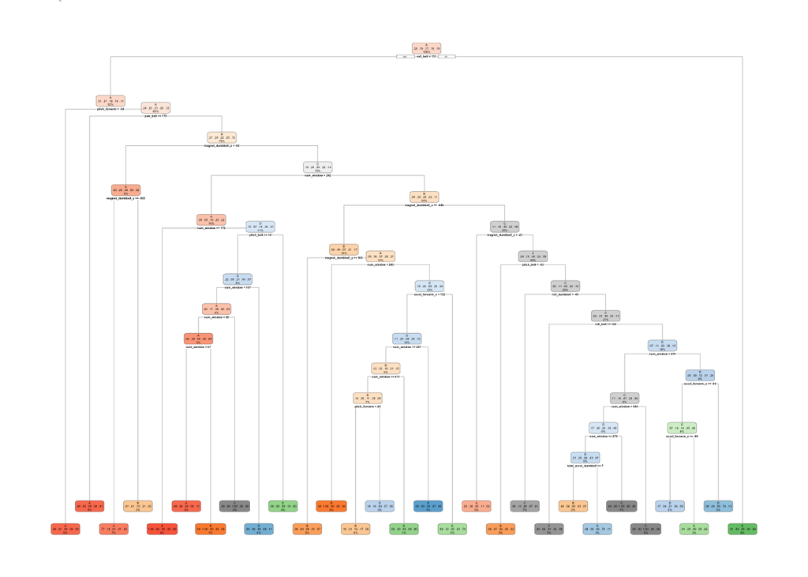

```r
set.seed(123)
DecTree <- rpart(classe ~ ., data=myTrain, method="class")
rpart.plot(DecTree)
```

```r
predictDecTree <- predict(DecTree, newdata=myTest, type="class")
confDecTree <- confusionMatrix(predictDecTree, myTest$classe)
confDecTree
```

```
## Confusion Matrix and Statistics
##
##           Reference
## Prediction    A    B    C    D    E
##          A 2031  243   43   62   36
##          B   90 1044  135  110   62
##          C    0   76 1043   42    5
##          D   86   60  129  993  121
##          E   25   95   18   79 1218
##
## Overall Statistics
##
##                Accuracy : 0.8067
##                  95% CI : (0.7977, 0.8153)
##     No Information Rate : 0.2845
##     P-Value [Acc > NIR] : < 2.2e-16
##
##                   Kappa : 0.7547
##  Mcnemar's Test P-Value : < 2.2e-16
##
## Statistics by Class:
##
##                      Class: A Class: B Class: C Class: D Class: E
## Sensitivity            0.9099   0.6877   0.7624   0.7722   0.8447
## Specificity            0.9316   0.9373   0.9810   0.9396   0.9661
## Pos Pred Value         0.8410   0.7245   0.8945   0.7149   0.8488
## Neg Pred Value         0.9630   0.9260   0.9513   0.9546   0.9651
## Prevalence             0.2845   0.1935   0.1744   0.1639   0.1838
## Detection Rate         0.2589   0.1331   0.1329   0.1266   0.1552
## Detection Prevalence   0.3078   0.1837   0.1486   0.1770   0.1829
## Balanced Accuracy      0.9208   0.8125   0.8717   0.8559   0.9054
```

### Generalized Boosted Models

```r
set.seed(123)
controls <- trainControl(method = "repeatedcv", number = 5, repeats = 1)
GBM  <- train(classe ~ ., data=myTrain, method = "gbm",
                    trControl = controls, verbose = FALSE)
GBM$finalModel

predictGBM <- predict(GBM, newdata=myTest)
confGBM <- confusionMatrix(predictGBM, myTest$classe)
confGBM
```

```
## A gradient boosted model with multinomial loss function.
## 150 iterations were performed.
## There were 53 predictors of which 41 had non-zero influence.
## Confusion Matrix and Statistics
##
##           Reference
## Prediction    A    B    C    D    E
##          A 2232    9    0    0    1
##          B    0 1493   17    7    3
##          C    0   15 1346   19    5
##          D    0    1    4 1260   11
##          E    0    0    1    0 1422
##
## Overall Statistics
##
##                Accuracy : 0.9881
##                  95% CI : (0.9855, 0.9904)
##     No Information Rate : 0.2845
##     P-Value [Acc > NIR] : < 2.2e-16
##
##                   Kappa : 0.985
##  Mcnemar's Test P-Value : NA
##
## Statistics by Class:
##
##                      Class: A Class: B Class: C Class: D Class: E
## Sensitivity            1.0000   0.9835   0.9839   0.9798   0.9861
## Specificity            0.9982   0.9957   0.9940   0.9976   0.9998
## Pos Pred Value         0.9955   0.9822   0.9718   0.9875   0.9993
## Neg Pred Value         1.0000   0.9960   0.9966   0.9960   0.9969
## Prevalence             0.2845   0.1935   0.1744   0.1639   0.1838
## Detection Rate         0.2845   0.1903   0.1716   0.1606   0.1812
## Detection Prevalence   0.2858   0.1937   0.1765   0.1626   0.1814
## Balanced Accuracy      0.9991   0.9896   0.9889   0.9887   0.9930
```

## Results

The accuracies of the 3 models are as listed below:

1. Random Forest: 0.9978
2. Decision Tree: 0.8067
3. GBM: 0.9881

## Predictions

The results for the RF Predictions are as follows:

```r
predict(RandForest, newdata=testing_data)
```

```
##  [1] B A B A A E D B A A B C B A E E A B B B
## Levels: A B C D E
```

```r
predict(RandForest, newdata=testing_data)
```

```
##  [1] B A B A A E D B A A B C B A E E A B B B
## Levels: A B C D E
```

The results for decision Trees are slightly different:

```r
predict(DecTree, newdata=testing_data,type = "class")
```

```
##  1  2  3  4  5  6  7  8  9 10 11 12 13 14 15 16 17 18 19 20
##  B  A  B  A  A  E  D  B  A  A  E  C  B  A  E  E  A  A  B  B
## Levels: A B C D E
```

Since the accuracy for Decision Trees is the lowest, we will disreguard that result.